# OkCupid Data

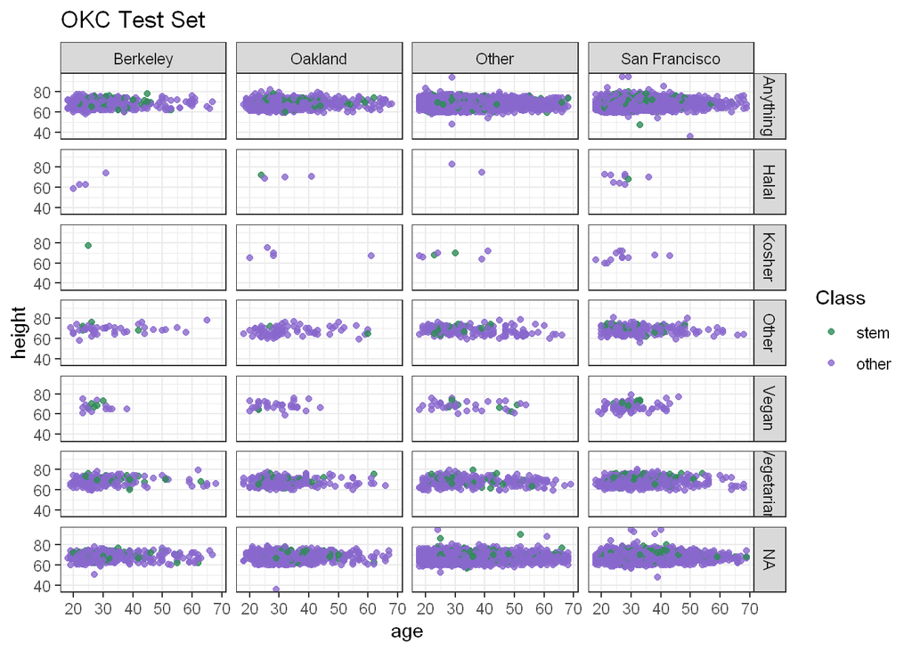

```r
ggplot(okc_test,aes(x=age,y=height,col=Class))+
  geom_point(alpha=0.8)+
  theme_bw()+
  facet_grid(diet~location)+
  scale_color_manual(values = c("seagreen","mediumpurple3"))+
  labs(title="OKC Test Set")
```

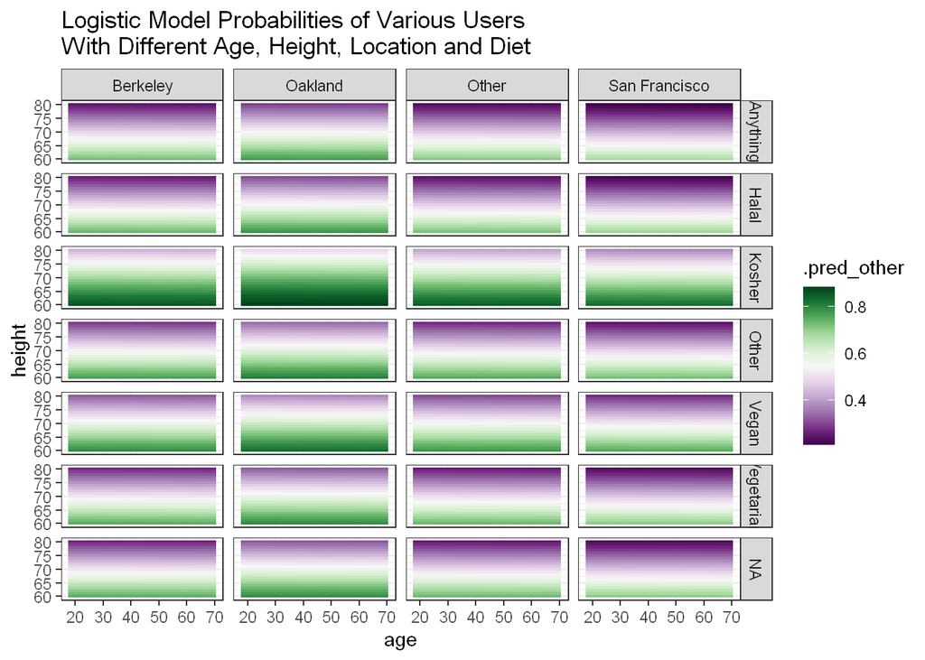

```r
predict(lgst_fit,new_data=fake_data_2,type="prob") %>%
  #rename(Pred =  .pred_class) %>%
  bind_cols(fake_data_2) %>%
  ggplot(aes(x=age,y=height,fill=.pred_other))+
  geom_tile()+
  theme_bw()+
  facet_grid(diet~location)+
  scale_fill_gradientn(colours =  RColorBrewer::brewer.pal(n = 11, name = 'PRGn'))+
  #scale_fill_brewer(palette = RColorBrewer::brewer.pal(n = 10, name = 'PRGn'))+
  labs(title="Logistic Model Probabilities of Various Users\nWith Different Age, Height, Location and Diet")
```

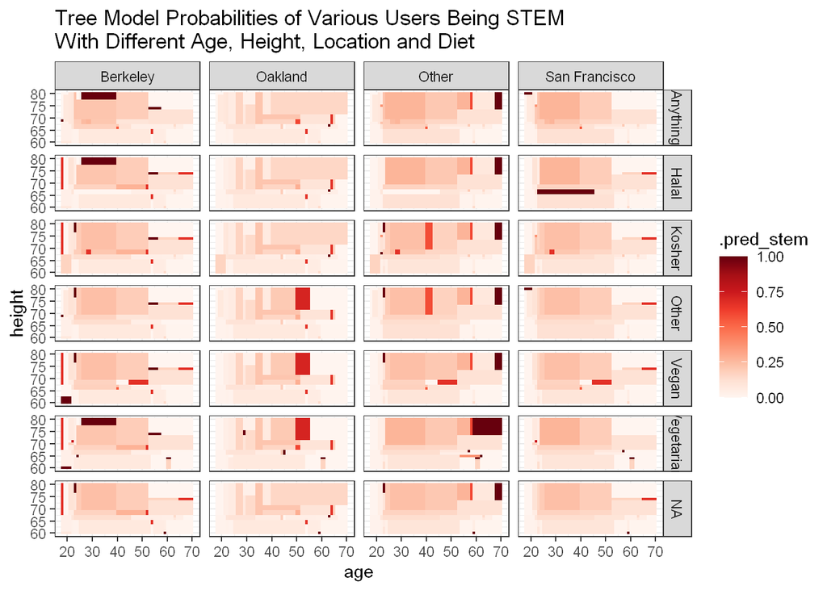

```r
predict(final_tree,new_data=fake_data_2,type="prob") %>%
  #rename(Pred =  .pred_class) %>%
  bind_cols(fake_data_2) %>%
  ggplot(aes(x=age,y=height,fill=.pred_stem))+
  geom_tile()+
  theme_bw()+
  facet_grid(diet~location)+
  scale_fill_gradientn(colours =  RColorBrewer::brewer.pal(n=9,name="Reds"))+
  labs(title="Tree Model Probabilities of Various Users Being STEM\nWith Different Age, Height, Location and Diet")
```

# 5 Conclusion

It appears that it is difficult to predict whether a user has a STEM Major. Perhaps using something like a Random Forest or KNN may yield better results, as it can model complex interactions. Either way, it appears using simple approaches does not give good results.

We also have a large class imbalance, to remedy this problem, using something like the SMOTE algorithm to create synthetic data may help.

Another approach would be to combine the two models in order to create an ensemble model. We can also add other models to get better predictions. The Logistic model was much better in finding the true positives, while the Decision Tree was poor in this regard.

It could also be the case that we just don’t have enough good, quality data to predict such a rare event. If we had other features, we could perhaps be in a better position to predict better.